# Socialmedia

Deviprasad Saka

2024-03-28

```r
sm <- read.csv("C:/Users/sakad/Downloads/social_media_cleaned.csv")
str(sm)
```

```
## 'data.frame':    21 obs. of  10 variables:
##  $ character                    : chr  "masinl" "peace" "Patty" "Bunny" ...
##  $ Instagram                    : num  3.5 7.73 3.77 5.38 12 2.33 5.37 7 8.65 0.17 ...
##  $ LinkedIn                     : num  4 5.2 7 5.32 0.58 7 4 4 10 0 ...
##  $ SnapChat                     : num  1 3.68 0.53 1.3 0 0.47 0 3 3.83 0 ...
##  $ Twitter                      : num  5 0 0 0 0.67 0 0 0 0 0 ...
##  $ Whatsapp.Wechat              : num  1 4.18 9.83 5.3 3 12 6 10 6.15 1 ...
##  $ youtube                      : num  2.5 4.25 1.85 2 3.5 7 3 2 4 3 ...
##  $ OTT                          : num  14.5 0 2 2 2 3 0 3 3 0 ...
##  $ Reddit                       : num  2.5 0 0 0 1 0 0 0 0 0 ...
##  $ How.you.felt.the.entire.week.: int  3 3 4 4 3 5 4 4 3 2 ...
```

```r
sm1 <- sm[, 2:9]
sm1
```

```
##    Instagram LinkedIn SnapChat Twitter Whatsapp.Wechat youtube   OTT Reddit
## 1       3.50     4.00     1.00    5.00            1.00    2.50 14.50   2.50
## 2       7.73     5.20     3.68    0.00            4.18    4.25  0.00   0.00
## 3       3.77     7.00     0.53    0.00            9.83    1.85  2.00   0.00
## 4       5.38     5.32     1.30    0.00            5.30    2.00  2.00   0.00
## 5      12.00     0.58     0.00    0.67            3.00    3.50  2.00   1.00
## 6       2.33     7.00     0.47    0.00           12.00    7.00  3.00   0.00
## 7       5.37     4.00     0.00    0.00            6.00    3.00  0.00   0.00
## 8       7.00     4.00     3.00    0.00           10.00    2.00  3.00   0.00
## 9       8.65    10.00     3.83    0.00            6.15    4.00  3.00   0.00
## 10      0.17     0.00     0.00    0.00            1.00    3.00  0.00   0.00
## 11      4.58     2.13     0.42    2.42            1.00    1.00  0.00   0.00
## 12      3.33     2.50     0.33    2.83            3.67    2.50  1.50   0.00
## 13      5.30     1.52    14.87    0.00            4.02    0.54  0.51   0.01
## 14      6.00     3.00     1.00    1.00            3.42    2.50  1.00   0.00
## 15      4.65     3.75     1.42    0.00            6.50    3.13  1.92   7.00
## 16      7.00     5.00     0.42    0.00            5.00    5.00  1.00   0.50
## 17      9.80     0.80     0.00    0.27           13.35    3.53  1.68   0.00
## 18      6.80     1.92     1.87    0.00            6.95    0.80  2.47   0.00
## 19      5.67     3.92     0.00    0.00            8.92    5.15  0.00   0.00
## 20     15.02     3.95     7.32    0.00           15.35    5.17 10.00   0.00
## 21      0.33     0.52     0.00    0.00            8.38    0.00  0.00   0.00
```

PCA Q: How do relation between social media platforms inform our understanding of user behavior and interactions?

```r
#Get the correlations between the variables
cor(sm1, use = "complete.obs")
```

```
##                   Instagram     LinkedIn    SnapChat    Twitter Whatsapp.Wechat
## Instagram        1.00000000  0.096836443  0.28970103 -0.1927972      0.37784893
## LinkedIn         0.09683644  1.000000000  0.02529643 -0.1306175      0.22899698
## SnapChat         0.28970103  0.025296428  1.00000000 -0.1801613      0.08104862
## Twitter         -0.19279717 -0.130617547 -0.18016133  1.0000000     -0.49574787
## Whatsapp.Wechat  0.37784893  0.228996980  0.08104862 -0.4957479      1.00000000
## youtube          0.33021732  0.452160243 -0.15977901 -0.1881819      0.37182165
## OTT              0.26738411  0.185463793  0.13165277  0.5569830      0.13356020
## Reddit          -0.07458765 -0.007079162 -0.08096904  0.1649095     -0.13445849
##                     youtube       OTT       Reddit
## Instagram        0.33021732 0.2673841 -0.074587647
## LinkedIn         0.45216024 0.1854638 -0.007079162
## SnapChat        -0.15977901 0.1316528 -0.080969036
## Twitter         -0.18818187 0.5569830  0.164909542
## Whatsapp.Wechat  0.37182165 0.1335602 -0.134458488
## youtube          1.00000000 0.1607195  0.026007762
## OTT              0.16071951 1.0000000  0.232981971
## Reddit           0.02600776 0.2329820  1.000000000
```

The result is a correlation matrix showing the relationships between different social media platforms based on their usage patterns or user engagement. Each cell in the matrix represents the correlation coefficient between pairs of platforms, ranging from -1 to 1. A value of 1 indicates a perfect positive correlation (when one platform’s usage increases, the other’s also tends to increase), while -1 indicates a perfect negative correlation (when one platform’s usage increases, the other’s tends to decrease).

For instance, the correlation between Instagram and LinkedIn is 0.097, suggesting a weak positive correlation, implying that users who engage more with Instagram may also have a slight tendency to engage more with LinkedIn. Conversely, the correlation between Twitter and Whatsapp/Wechat is -0.496, indicating a moderate negative correlation, implying that users who are highly active on Twitter may be less active on Whatsapp/Wechat, and vice versa.

The diagonal elements (where the platform is compared to itself) always have a correlation coefficient of 1 since a platform perfectly correlates with itself. This matrix helps understand how different social media platforms are related to each other in terms of user engagement or usage patterns, which can be valuable for marketers, researchers, and social media strategists in understanding user behavior and optimizing their strategies across multiple platforms.

Q: What are the implications of the rotated factor loadings on social media platforms in understanding their associations and contributions to different dimensions captured by principal components in factor analysis or principal component analysis?

```r
#Computing Principal Components
social_pca <- prcomp(sm1,scale=TRUE)
social_pca
```

```
## Standard deviations (1, .., p=8):
## [1] 1.4937855 1.3062652 1.1302644 0.9384154 0.9007773 0.7693882 0.6079359
## [8] 0.3622309
##
## Rotation (n x k) = (8 x 8):
##                         PC1         PC2          PC3         PC4         PC5
## Instagram        0.43528749 -0.15383754  0.378064635  0.03091067  0.36691411
## LinkedIn         0.35654047 -0.20942720 -0.329973958 -0.19635277 -0.70307433
## SnapChat         0.15951942  0.03373703  0.717834288  0.10382304 -0.50998908
## Twitter         -0.39042544 -0.53811531  0.040061762 -0.33459600  0.09394086
## Whatsapp.Wechat  0.52692924  0.06069670  0.007260553  0.09076207  0.28302310
## youtube          0.45376608 -0.20713849 -0.406499207 -0.03646460  0.09495664
## OTT              0.08164899 -0.68438404  0.215954720 -0.12833890  0.07485857
## Reddit          -0.12369550 -0.35608430 -0.139149370  0.90095400 -0.08616338
##                         PC6         PC7         PC8
## Instagram       -0.51106683 -0.48946149  0.08707842
## LinkedIn         0.02588829 -0.42218323  0.09143040
## SnapChat        -0.04950250  0.39275988  0.17478671
## Twitter         -0.02565582  0.04598525  0.65790782
## Whatsapp.Wechat  0.68945551  0.02304825  0.39292343
## youtube         -0.39820221  0.64499580  0.03189625
## OTT              0.31729474  0.06579314 -0.59265177
## Reddit          -0.02102173 -0.07024430  0.11841633
```

The provided result represents the rotated factor loadings from a factor analysis or principal component analysis (PCA) of various social media platforms. In such analyses, multiple variables (in this case, social media platforms) are examined to identify underlying factors or components that explain the shared variance among them. The table shows the loadings of each social media platform on the identified principal components (PCs), denoted as PC1 through PC8. Each row corresponds to a social media platform, and each column represents a principal component.

These loadings represent the correlation between each social media platform and the identified components. Higher absolute values (close to 1) suggest a stronger relationship, while values closer to 0 indicate a weaker association. The rotated factor loadings help in interpreting the underlying structure of the data, revealing which social media platforms are closely related and how they contribute to different dimensions captured by the principal components.

```r
summary(social_pca)
```

```
## Importance of components:
##                           PC1    PC2    PC3    PC4    PC5     PC6    PC7    PC8
## Standard deviation     1.4938 1.3063 1.1303 0.9384 0.9008 0.76939 0.6079 0.3622
## Proportion of Variance 0.2789 0.2133 0.1597 0.1101 0.1014 0.07399 0.0462 0.0164
## Cumulative Proportion  0.2789 0.4922 0.6519 0.7620 0.8634 0.93740 0.9836 1.0000
```

```r
eigen_social<- social_pca$sdev^2
eigen_social
```

```
## [1] 2.2313950 1.7063288 1.2774976 0.8806234 0.8113997 0.5919581 0.3695861
## [8] 0.1312112
```

The PCA analysis reveals that PC1 and PC2 together contribute approximately 50% of the total variance.

Q: What the variance explained by each component, and how does it suggest the number of components to retain for analysis?

Screeplot

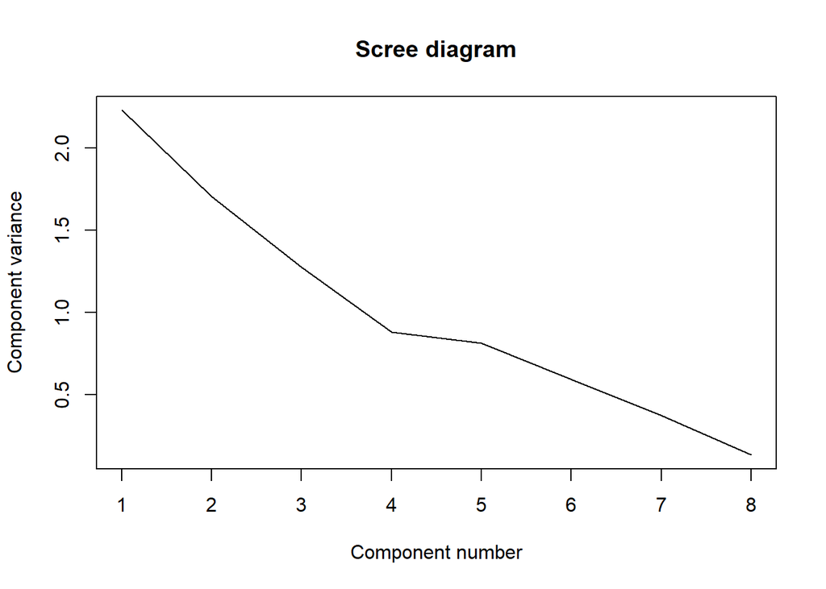

```r
plot(eigen_social, xlab = "Component number", ylab = "Component variance", type = "l", main = "Scree diagram")
```

From this Scree diagram, we can see that the first component has a variance just above 2.0, and the variance decreases with each additional component. The curve starts to flatten out after the third component, suggesting that retaining the first two or three components might be appropriate for this particular analysis. Components beyond this point are often considered to contribute less to explaining the variance and may be less meaningful.

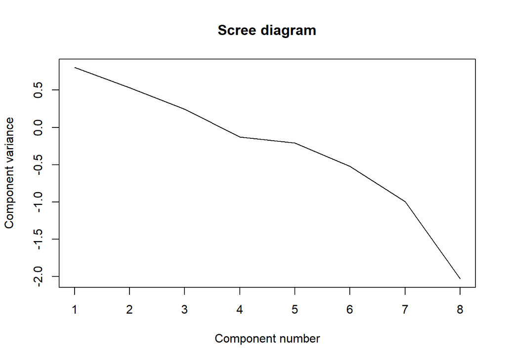

```r
plot(log(eigen_social), xlab = "Component number", ylab = "Component variance", type = "l", main = "Scree diagram")
```

Visualization using Principal Components

```r
library(FactoMineR)
library("factoextra")
```

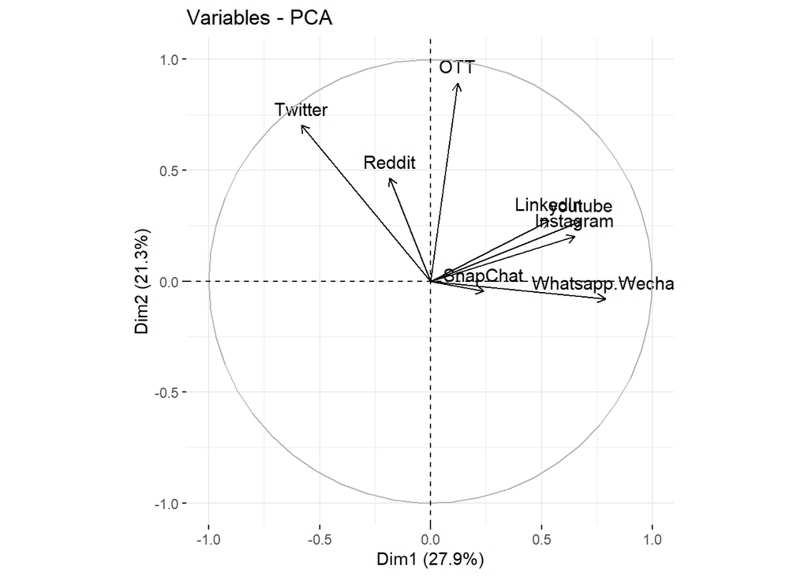

```r
res.pca <- PCA(sm1, graph = FALSE)
fviz_pca_var(res.pca, col.var = "black")
```

Factor Analysis

```r
# load library for factor analysis
library(ggplot2)
library(psych)
```

Q: Determine the optimal number of factors for your dataset?

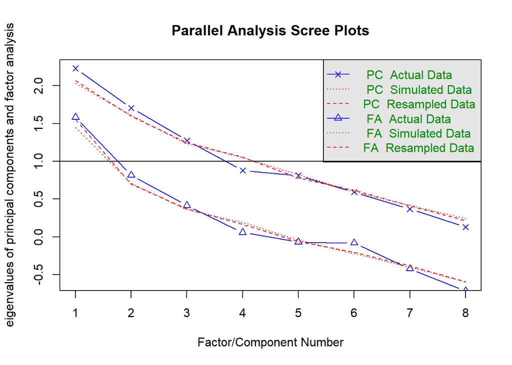

```
## Parallel analysis suggests that the number of factors =  0  and the number of components =  0
```

```r
fa.parallel(sm1)
```

Parallel analysis indicates that both the number of factors and the number of components are zero.

Q: Provide an explanation for the output of your factor model?

```r
fit.pc <- principal(sm1, nfactors=2, rotate="varimax")
fit.pc
```

```
## Principal Components Analysis
## Call: principal(r = sm1, nfactors = 2, rotate = "varimax")
## Standardized loadings (pattern matrix) based upon correlation matrix
##                   RC1   RC2    h2   u2 com
## Instagram        0.68  0.01 0.463 0.54 1.0
## LinkedIn         0.59  0.11 0.358 0.64 1.1
## SnapChat         0.22 -0.11 0.059 0.94 1.5
## Twitter         -0.36  0.84 0.834 0.17 1.4
## Whatsapp.Wechat  0.73 -0.30 0.626 0.37 1.3
## youtube          0.73  0.07 0.533 0.47 1.0
## OTT              0.37  0.82 0.814 0.19 1.4
## Reddit          -0.04  0.50 0.250 0.75 1.0
##
##                        RC1  RC2
## SS loadings           2.19 1.75
## Proportion Var        0.27 0.22
## Cumulative Var        0.27 0.49
## Proportion Explained  0.56 0.44
## Cumulative Proportion 0.56 1.00
##
## Mean item complexity =  1.2
## Test of the hypothesis that 2 components are sufficient.
##
## The root mean square of the residuals (RMSR) is  0.13
##  with the empirical chi square  21.05  with prob <  0.072
##
## Fit based upon off diagonal values = 0.71
```

- Large absolute values (near 1) signify a robust association between the variable and the factor.
- h2 quantifies the extent to which factors account for variable variance.
- u2 denotes the portion of variance not captured by the factors.

[output not shown]

```r
round(fit.pc$values, 3)
```

```
## [1] 2.231 1.706 1.277 0.881 0.811 0.592 0.370 0.131
```

```r
fit.pc$loadings
```

```
##
## Loadings:
##                 RC1    RC2
## Instagram        0.681
## LinkedIn         0.588  0.111
## SnapChat         0.216 -0.110
## Twitter         -0.359  0.840
## Whatsapp.Wechat  0.732 -0.300
## youtube          0.727
## OTT              0.371  0.822
## Reddit                  0.498
##
##                  RC1   RC2
## SS loadings    2.189 1.749
## Proportion Var 0.274 0.219
## Cumulative Var 0.274 0.492
```

```r
# Communalities
fit.pc$communality
```

```
##       Instagram        LinkedIn        SnapChat         Twitter Whatsapp.Wechat
##       0.4631760       0.3584966       0.0587232       0.8342344       0.6258430
##         youtube             OTT          Reddit
##       0.5326647       0.8140886       0.2504973
```

```r
# Rotated factor scores, Notice the columns ordering: RC1, RC2
fit.pc
```

```
## Principal Components Analysis
## Call: principal(r = sm1, nfactors = 2, rotate = "varimax")
## Standardized loadings (pattern matrix) based upon correlation matrix
##                   RC1   RC2    h2   u2 com
## Instagram        0.68  0.01 0.463 0.54 1.0
## LinkedIn         0.59  0.11 0.358 0.64 1.1
## SnapChat         0.22 -0.11 0.059 0.94 1.5
## Twitter         -0.36  0.84 0.834 0.17 1.4
## Whatsapp.Wechat  0.73 -0.30 0.626 0.37 1.3
## youtube          0.73  0.07 0.533 0.47 1.0
## OTT              0.37  0.82 0.814 0.19 1.4
## Reddit          -0.04  0.50 0.250 0.75 1.0
##
##                        RC1  RC2
## SS loadings           2.19 1.75
## Proportion Var        0.27 0.22
## Cumulative Var        0.27 0.49
## Proportion Explained  0.56 0.44
## Cumulative Proportion 0.56 1.00
##
## Mean item complexity =  1.2
## Test of the hypothesis that 2 components are sufficient.
##
## The root mean square of the residuals (RMSR) is  0.13
##  with the empirical chi square  21.05  with prob <  0.072
##
## Fit based upon off diagonal values = 0.71
```

```r
fit.pc$scores
```

```
##               RC1         RC2
##  [1,] -0.49624055  3.81931118
##  [2,]  0.37381791 -0.45829983
##  [3,]  0.24026578 -0.39773035
##  [4,] -0.11813877 -0.28581917
##  [5,] -0.05612179  0.18892772
##  [6,]  1.33950136 -0.15489910
##  [7,] -0.16510634 -0.57411254
##  [8,]  0.36248103 -0.37606120
##  [9,]  1.27363310  0.04673432
## [10,] -1.47442593 -0.57714722
## [11,] -1.47172675  0.33207687
## [12,] -0.99536049  0.65208895
## [13,] -0.64535181 -0.84676594
## [14,] -0.54371772 -0.04386217
## [15,] -0.05085497  0.89227335
## [16,]  0.46515473 -0.19348386
## [17,]  0.63768723 -0.56192633
## [18,] -0.42546987 -0.44047678
## [19,]  0.50443809 -0.59824502
## [20,]  2.63331377  0.51395273
## [21,] -1.38777801 -0.93653561
```

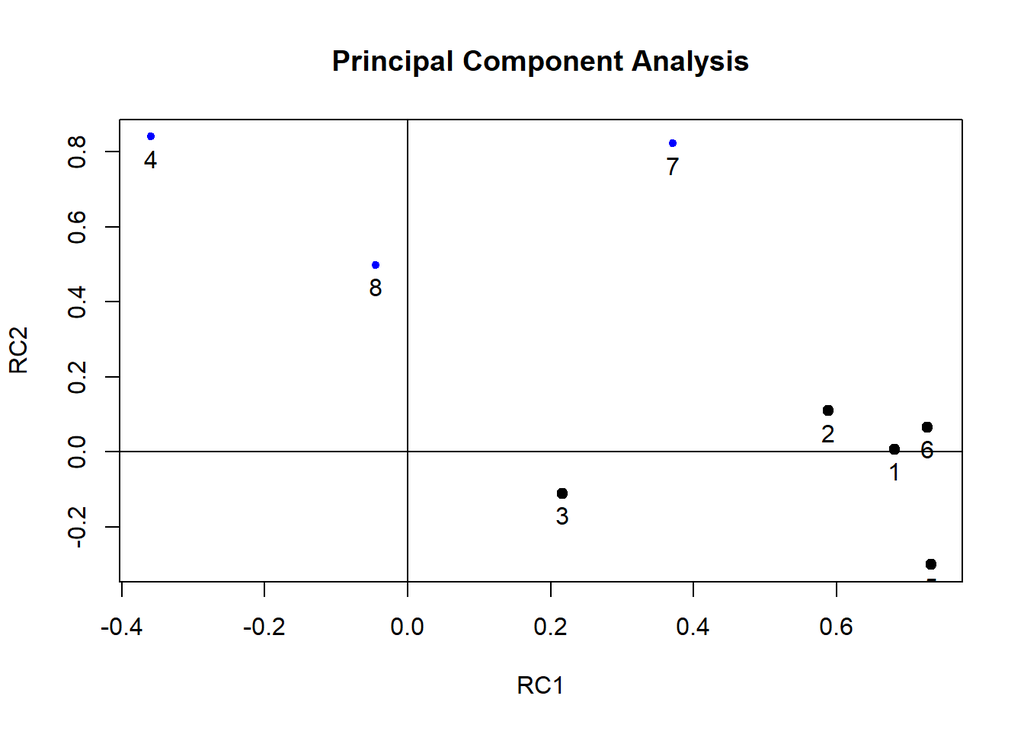

```r
fa.plot(fit.pc) # See Correlations within Factors
```

Q: Show the columns that go into each factor?

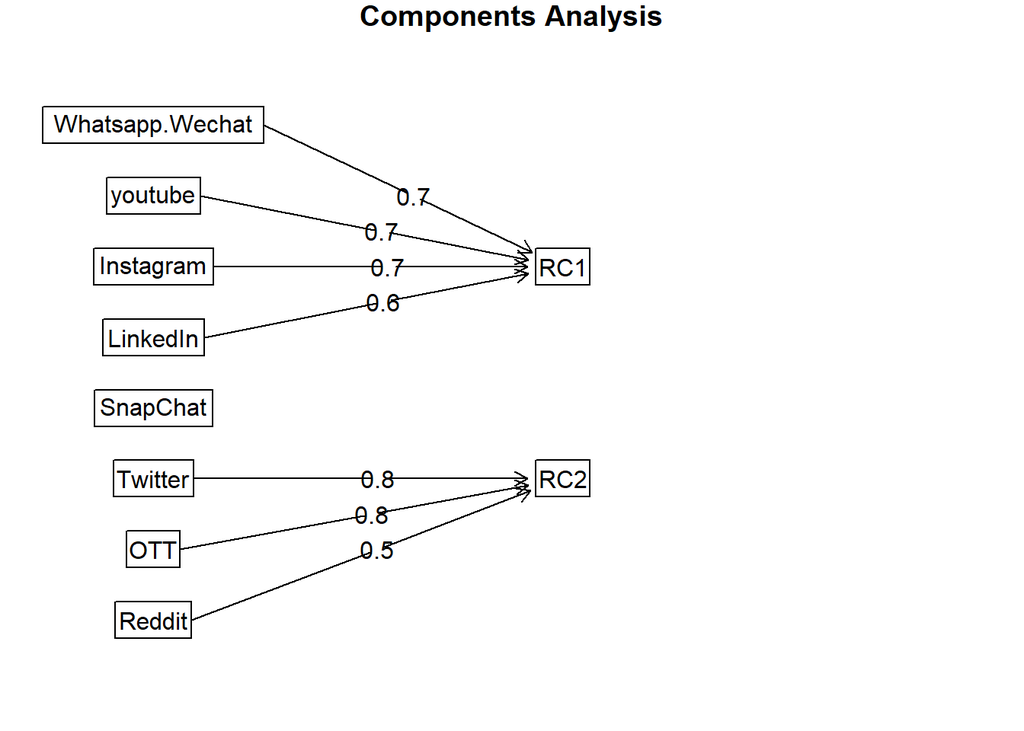

```r
fa.diagram(fit.pc) # Visualize the relationship
```

This displays a diagram titled “Components Analysis,” which seems to represent a factor analysis or a similar statistical method that groups different social media platforms into components based on their relationships. The platforms listed are WhatsApp/WeChat, YouTube, Instagram, LinkedIn, SnapChat, Twitter, OTT, and Reddit.

Creating visual representations utilizing the factors.

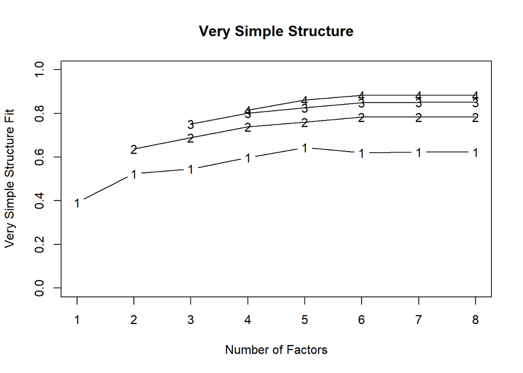

```
##
## Very Simple Structure
## Call: vss(x = sm1)
## VSS complexity 1 achieves a maximimum of 0.64  with  5  factors
## VSS complexity 2 achieves a maximimum of 0.78  with  7  factors
##
## The Velicer MAP achieves a minimum of 0.07  with  1  factors
## BIC achieves a minimum of  -35.55  with  1  factors
## Sample Size adjusted BIC achieves a minimum of  1.71  with  4  factors
##
## Statistics by number of factors
##   vss1 vss2   map dof   chisq prob sqresid  fit RMSEA   BIC SABIC complex
## 1 0.39 0.00 0.071  20 2.5e+01 0.19     7.0 0.39   0.1 -35.6  26.2     1.0
## 2 0.52 0.64 0.090  13 8.9e+00 0.78     4.2 0.64   0.0 -30.7   9.4     1.2
## 3 0.55 0.69 0.117   7 4.7e+00 0.70     2.9 0.75   0.0 -16.6   5.0     1.5
## 4 0.60 0.74 0.179   2 1.6e+00 0.44     2.1 0.81   0.0  -4.5   1.7     1.5
## 5 0.64 0.76 0.271  -2 6.5e-01   NA     1.5 0.87    NA    NA    NA     1.3
## 6 0.62 0.78 0.442  -5 4.5e-10   NA     1.2 0.90    NA    NA    NA     1.5
## 7 0.62 0.78 1.000  -7 0.0e+00   NA     1.2 0.90    NA    NA    NA     1.5
## 8 0.62 0.78    NA  -8 0.0e+00   NA     1.2 0.90    NA    NA    NA     1.5
##    eChisq    SRMR eCRMS  eBIC
## 1 3.2e+01 1.7e-01 0.196 -28.5
## 2 9.2e+00 8.8e-02 0.130 -30.4
## 3 2.1e+00 4.2e-02 0.084 -19.2
## 4 8.0e-01 2.6e-02 0.097  -5.3
## 5 2.2e-01 1.4e-02    NA    NA
## 6 1.8e-10 3.9e-07    NA    NA
## 7 2.2e-18 4.3e-11    NA    NA
## 8 2.2e-18 4.3e-11    NA    NA
```

```r
#very simple structure visualization
vss(sm1)
```

```r
# Computing Correlation Matrix
corrm.social <- cor(sm1)
corrm.social
```

```
##                   Instagram     LinkedIn    SnapChat    Twitter Whatsapp.Wechat
## Instagram        1.00000000  0.096836443  0.28970103 -0.1927972      0.37784893
## LinkedIn         0.09683644  1.000000000  0.02529643 -0.1306175      0.22899698
## SnapChat         0.28970103  0.025296428  1.00000000 -0.1801613      0.08104862
## Twitter         -0.19279717 -0.130617547 -0.18016133  1.0000000     -0.49574787
## Whatsapp.Wechat  0.37784893  0.228996980  0.08104862 -0.4957479      1.00000000
## youtube          0.33021732  0.452160243 -0.15977901 -0.1881819      0.37182165
## OTT              0.26738411  0.185463793  0.13165277  0.5569830      0.13356020
## Reddit          -0.07458765 -0.007079162 -0.08096904  0.1649095     -0.13445849
##                     youtube       OTT       Reddit
## Instagram        0.33021732 0.2673841 -0.074587647
## LinkedIn         0.45216024 0.1854638 -0.007079162
## SnapChat        -0.15977901 0.1316528 -0.080969036
## Twitter         -0.18818187 0.5569830  0.164909542
## Whatsapp.Wechat  0.37182165 0.1335602 -0.134458488
## youtube          1.00000000 0.1607195  0.026007762
## OTT              0.16071951 1.0000000  0.232981971
## Reddit           0.02600776 0.2329820  1.000000000
```

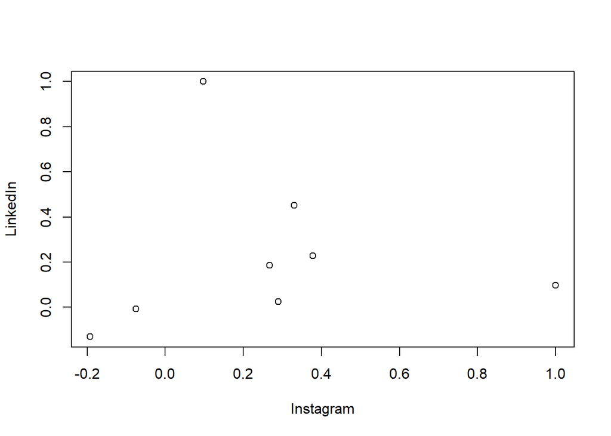

```r
plot(corrm.social)
```

Q: What is the significance of each principal component in explaining the variance and capturing the underlying structure of the data in the factor analysis?

```r
social_pca <- prcomp(sm1, scale=TRUE)
summary(social_pca)
```

```
## Importance of components:
##                           PC1    PC2    PC3    PC4    PC5     PC6    PC7    PC8
## Standard deviation     1.4938 1.3063 1.1303 0.9384 0.9008 0.76939 0.6079 0.3622
## Proportion of Variance 0.2789 0.2133 0.1597 0.1101 0.1014 0.07399 0.0462 0.0164
## Cumulative Proportion  0.2789 0.4922 0.6519 0.7620 0.8634 0.93740 0.9836 1.0000
```

The results represents the importance of each principal component (PC) in the factor analysis. The standard deviation indicates the variability captured by each PC, with PC1 having the highest at 1.4937 and subsequent PCs decreasing in magnitude. The proportion of variance signifies the percentage of total variance explained by each PC, with PC1 contributing the most at 27.89% and subsequent PCs decreasing in importance. The cumulative proportion shows the accumulated contribution of each PC to the total variance, with PC1 accounting for 27.89% and subsequent PCs incrementally adding to reach 100%. This information helps understand the significance of each PC in capturing the underlying structure of the data, with PC1 being the most influential, followed by subsequent PCs in descending order of importance.

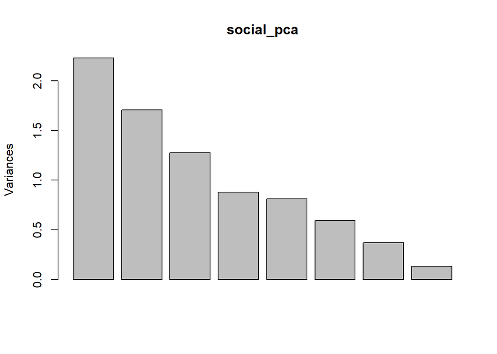

```r
plot(social_pca)
```

Q: What are the main insights obtained from the relationship between social media platforms and individual observations in the factor analysis? Biplot

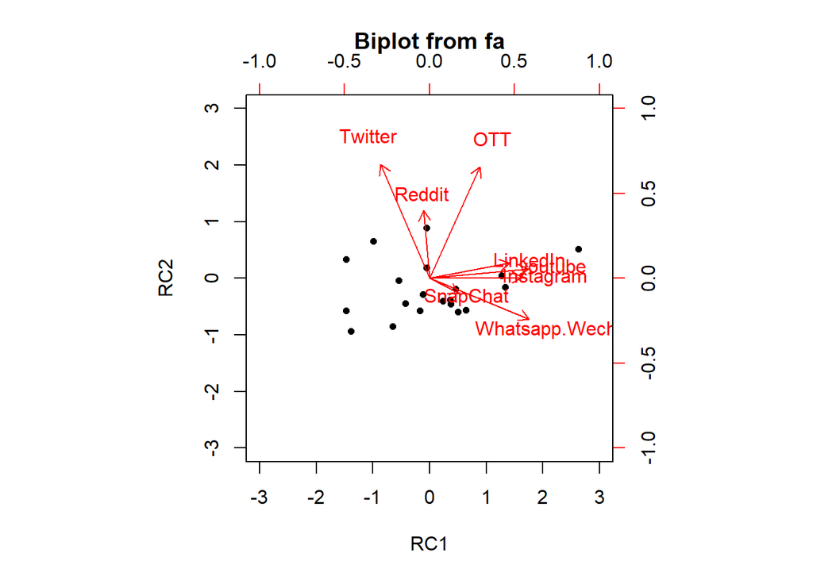

```r
biplot(fit.pc)
```

The biplot visualizes the results of a factor analysis, showing the relationship between various social media platforms and services (represented by red arrows) and the scores of individual observations (represented by black dots) across two principal components, RC1 and RC2. The social media platforms—Twitter, OTT content, Reddit, LinkedIn, YouTube, Instagram, Snapchat, and Whatsapp/Wechat—are plotted as vectors, with their direction and length indicating their contribution and correlation to the components. Platforms with similar orientations have similar factor profiles, suggesting comparable characteristics or usage patterns. The position of the data points indicates how each observation scores on the components, with clustering points suggesting groups with similar factor scores. The biplot is a useful tool for interpreting the underlying structure of the data, revealing the dominant patterns of variation and the relationships between the variables and observations.

Cluster Analysis

```r
library(MASS)
library(factoextra)
library(ggplot2)
library(readxl)
library(factoextra)
library(ggfortify)
library(ggrepel)
library(stats)

# Load required library
library(readxl)

# Define the file path
file_path <- "C:/Users/sakad/Downloads/social_media_cleaned.xlsx"

# Read the Excel file
body <- read_excel(file_path)

# Standardize the dataset excluding the first variable which is categorical
data.scaled <- scale(x = body[, -1], center = TRUE, scale = TRUE)

# Assign the standardized data to 'data'
data <- data.scaled

# Display the first few rows of 'data'
head(data)
```

```
##       Instagram   LinkedIn   SnapChat     Twitter Whatsapp/Wechat    youtube
## [1,] -0.6888867  0.1519097 -0.2810325  3.42451853      -1.3480276 -0.2719612
## [2,]  0.5146906  0.6366870  0.4933528 -0.44951033      -0.5576781  0.7352180
## [3,] -0.6130708  1.3638528 -0.4157082 -0.44951033       0.8450887 -0.6460563
## [4,] -0.1534369  0.6838181 -0.1944552 -0.44951033      -0.2804351 -0.5597267
## [5,]  1.7277449 -1.2283589 -0.5696232  0.06702685      -0.8514729  0.3035697
## [6,] -1.0205812  1.3638528 -0.4349475 -0.44951033       1.3830228  2.3179281
##             OTT     Reddit How you felt the entire week?
## [1,]  3.4382238  1.2405563                    -0.5741693
## [2,] -0.6686547 -0.3292004                    -0.5741693
## [3,] -0.1021887 -0.3292004                     0.7655590
## [4,] -0.1021887 -0.3292004                     0.7655590
## [5,] -0.1021887  0.2987023                    -0.5741693
## [6,]  0.1810443 -0.3292004                     2.1052873
```

Q: What is the proportion of variance explained by the first three principal components in the PCA analysis, and how does it impact the effectiveness of the subsequent K-means clustering algorithm in identifying distinct clusters within the data?

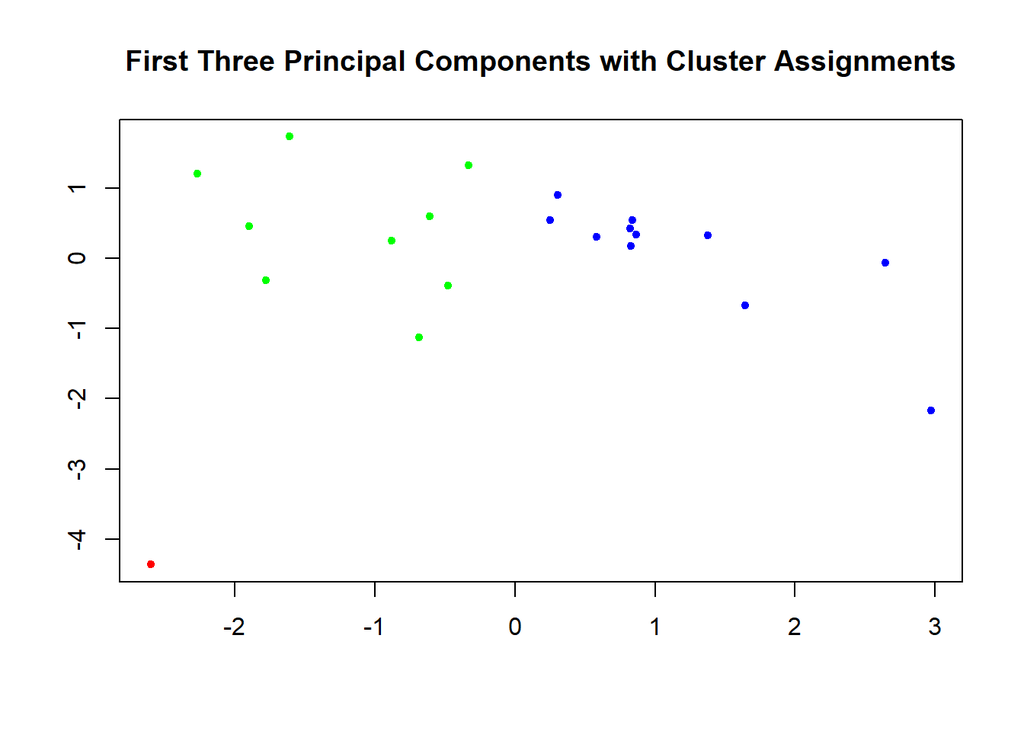

```r
# Perform PCA
pc <- prcomp(data.scaled)

# Extract the first three principal components
pc_first_three <- pc$x[, 1:3]

# Perform K-means clustering on the first three principal components
set.seed(123)  # For reproducibility
k <- 3  # Number of clusters
km_clusters <- kmeans(pc_first_three, centers = k)

# Define colors for each cluster
cluster_colors <- c("red", "blue", "green")

# Plot the first three principal components with cluster assignments
plot(pc_first_three, col = cluster_colors[km_clusters$cluster],
     main = "First Three Principal Components with Cluster Assignments",
     xlab = "", ylab = "", pch = 20)
```

This above code first performs Principal Component Analysis (PCA) on scaled data, reducing its dimensionality. Then, it extracts the first three principal components. Next, it applies K-means clustering to these components, dividing data into three clusters. Finally, it plots the first three principal components with color-coded cluster assignments for visualization and analysis.

Q: Can hierarchical clustering based on the first three principal components effectively reveal underlying patterns or groupings within the dataset, and how do the relationships between samples, as depicted in the dendrogram, reflect the distances in the reduced-dimensional space?

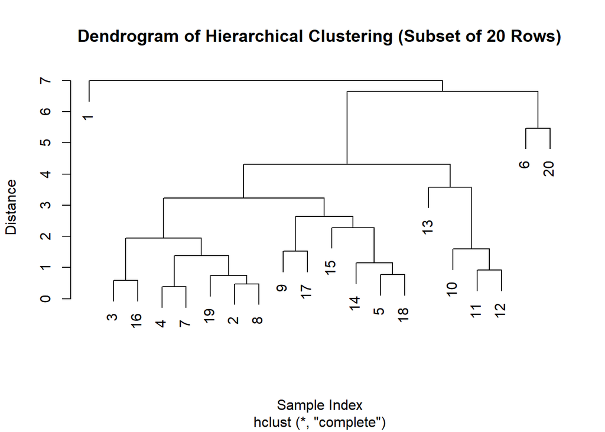

```r
# Perform PCA
pc <- prcomp(data.scaled)

# Extract the first three principal components
pc_first_three <- pc$x[, 1:3]

# Take a subset of 20 rows
data_subset <- data[1:20, ]

# Perform PCA
pca_result <- prcomp(data_subset)

# Extract the first three principal components
pc_first_three <- pca_result$x[, 1:3]

# Perform hierarchical clustering on the first three principal components
hc <- hclust(dist(pc_first_three))

# Plot the dendrogram
plot(hc, main = "Dendrogram of Hierarchical Clustering (Subset of 20 Rows)",
     xlab = "Sample Index", ylab = "Distance", sub = NULL)
```

The plot shows the first three principal components, performs hierarchical clustering on them, and plots a dendrogram showing the relationships between the samples based on their distances in the reduced-dimensional space.

Q: What is the degree of separation or distinctiveness among the identified clusters when analyzing the distribution of data points in the two-dimensional space formed by the first two Principal Components?

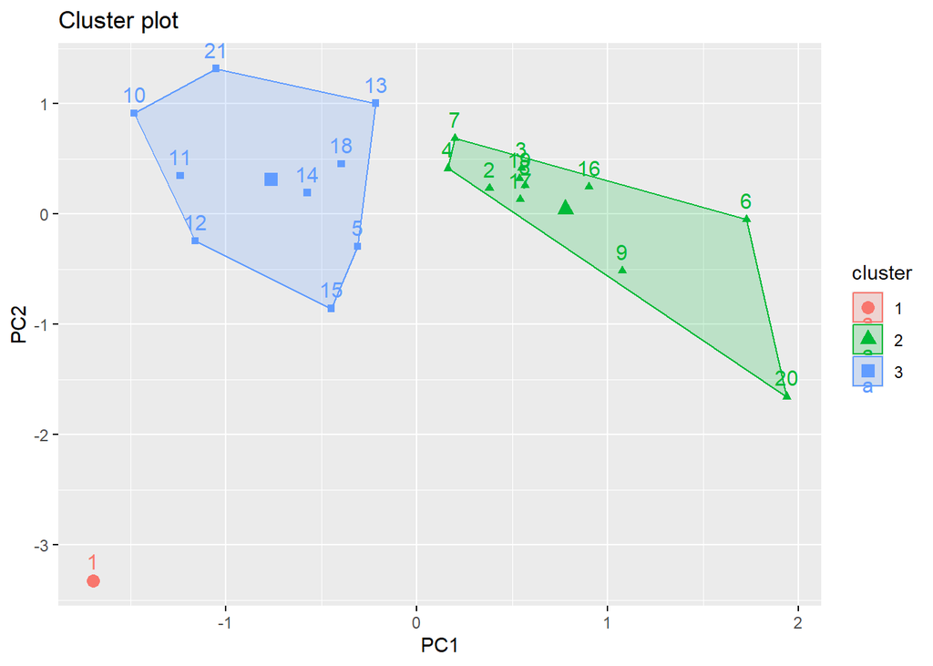

```r
# Visualize cluster and membership using first two Principal Components
fviz_cluster(list(data = pc$x[, 1:2], cluster = km_clusters$cluster))
```

This plot visualizes clustering results by plotting data points in a two-dimensional space using the first two Principal Components. Each point is colored according to its assigned cluster, showing the grouping pattern identified by the clustering algorithm. It helps understand how data points are grouped based on their features.

```r
# Non-hierarchical clustering (k-means)
num_clusters <- 2
kmeans_model <- kmeans(data, centers = num_clusters)

# Membership for each cluster
table(kmeans_model$cluster)
```

```
##
##  1  2
## 11 10
```

This represents clustering using the k-means algorithm, dividing data into two clusters. It initializes cluster centers randomly, assigning each data point to the nearest cluster. The table function counts the number of data points assigned to each cluster, providing insight into cluster membership and distribution.

Q: What is the distribution of cluster sizes obtained through k-means clustering when applied to the dataset using the first two principal components, and how does it compare to the distribution of cluster sizes obtained from clustering in the original feature space?

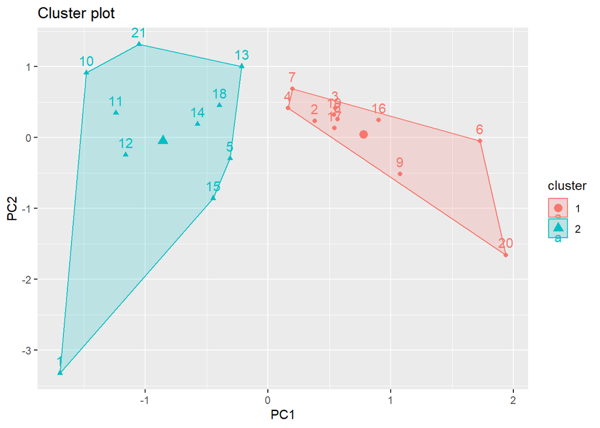

```r
# Visualize cluster and membership using first two Principal Components
fviz_cluster(list(data = pc$x[, 1:2], cluster = kmeans_model$cluster))
```

This plot visualizes clusters and their memberships using the first two principal components. It extracts these components from the data, then assigns each data point to a cluster using k-means clustering. Finally, it creates a visual representation showing how the data points are grouped based on their similarities in the first two principal components.

Q: What is the relationship between the clustering results obtained through k-means algorithm and the underlying structure of the data as revealed by Principal Component Analysis (PCA)?

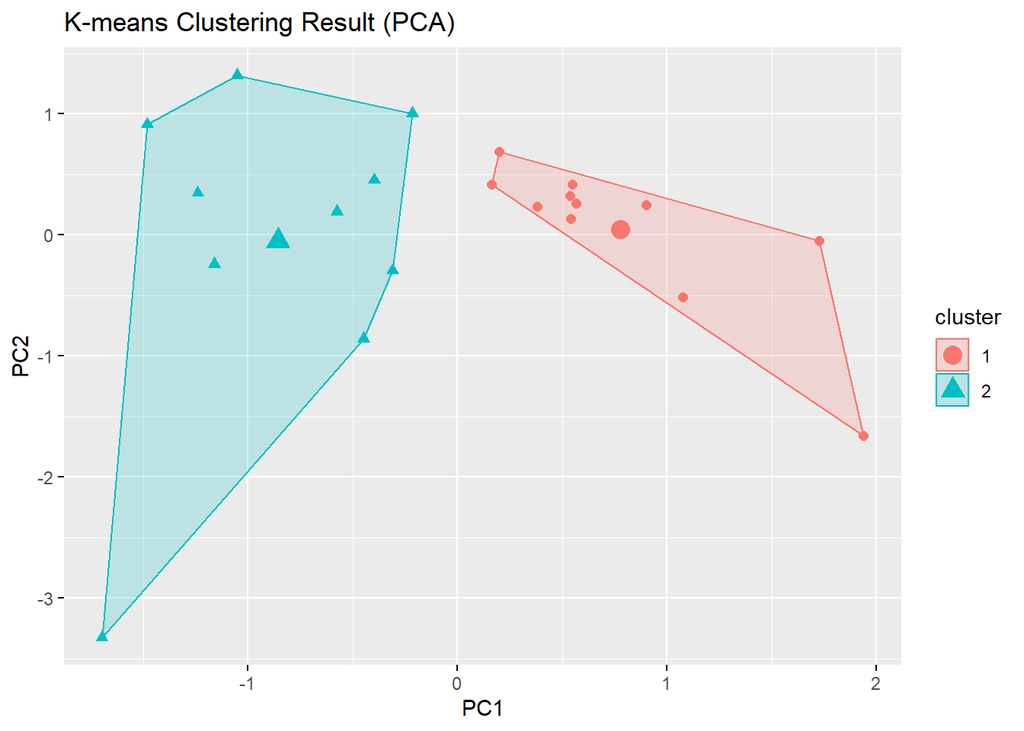

```r
# Visualize cluster and membership using first two Principal Components for k-means
pca_result <- prcomp(data, scale = TRUE)
fviz_cluster(kmeans_model, data = pca_result$x[, 1:2], geom = "point",
             pointsize = 2, fill = "white", main = "K-means Clustering Result (PCA)")
```

Q:What is the relationship between the number of clusters (k) and the average silhouette width in k-means clustering, and how does this relationship inform the determination of the optimal number of clusters for a given dataset?

```
##   cluster size ave.sil.width
## 1       1   11          0.26
## 2       2   10          0.04
```

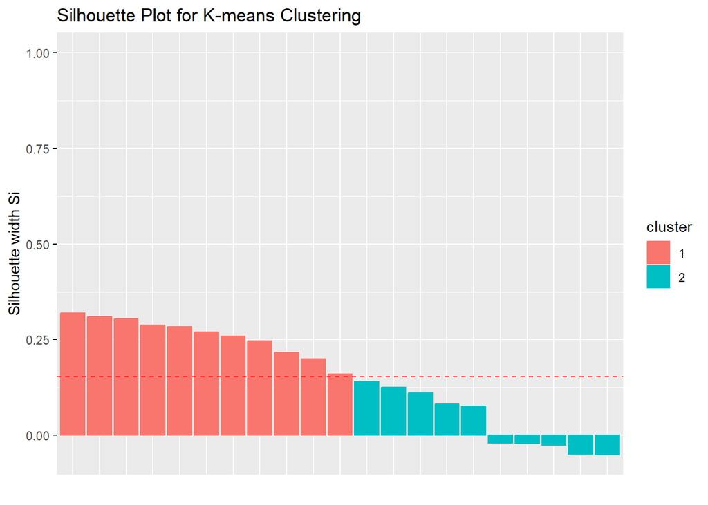

```r
library(factoextra)
library(cluster)

# Calculate silhouette information for k-means clustering
sil <- silhouette(kmeans_model$cluster, dist(data))

# Visualize the silhouette plot for k-means clustering
fviz_silhouette(sil, main = "Silhouette Plot for K-means Clustering")
```

This plot calculates and visualizes the silhouette information for k-means clustering. Silhouette analysis helps evaluate the quality of clustering by measuring how similar an object is to its own cluster compared to other clusters. A higher silhouette width indicates better separation of clusters, while negative values suggest that points might be assigned to the wrong clusters. This plot helps in determining the optimal number of clusters for k-means clustering and assessing the overall clustering performance.

Q: Is there a significant difference in the clustering patterns based on Linkedin and Youtube among different groups represented by distinct colors on the plot?

[figure not shown]

```r
# Create a data frame with cluster membership
data_clustered <- data.frame(data, Cluster = kmeans_model$cluster)  # Ensure conversion to data frame

# Scatter plot of data points colored by cluster membership
plot(data_clustered$LinkedIn, data_clustered$youtube,
     col = data_clustered$Cluster, pch = 16,
     xlab = "Linkedin", ylab = "youtube",
     main = "Scatter Plot of Clustering")
legend("topright", legend = unique(data_clustered$Cluster),
       col = 1:max(data_clustered$Cluster), pch = 16, title = "Cluster")
```

Overall, this plot visualizes clusters in the data, helping us understand how data points group together based on the Linkedin and Youtube, with each group represented by a different color on the plot.